# SST Validation and Comparison

## Purpose

We have developed environmental time series to test in the North Pacific humpback assessment model. To develop these time series, we used ocean model data from Copernicus Marine’s GLORYS models to balance our needs for a consistent product that covers the entire North Pacific, but is sufficiently high resolution to be relevant within each humpback feeding ground. However, as with any modeled data, we want to validate it to the extent possible against other sources of data. Here, we do that by comparing GLORYS-derived SST to SST from two other sources. The first is the Naval Oceanographic Office Group for High Resolution Sea Surface Temperature (GHRSST), a high-resolution, global satellite-derived SST product. The second is another ocean model, MOM6, which covers the US West Coast, Gulf of Alaska, and Bering Sea, but not the rest of the northwest Pacific.

## Import Data

### Feeding Zones

Zones in blue are areas for which we are interested in developing time series. Because the humpback assessment model uses multiple scenarios, there are some zones that are combinations of others. For example, the Western Gulf of Alaska is either its own zone (WGOA) or is included with the Eastern Aleutians and Bering Sea (EAL+BER+WGOA).

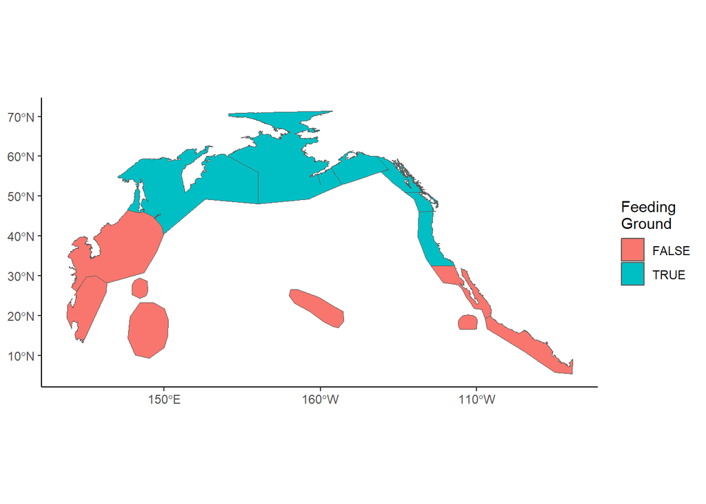

```r
zones <- read_sf(here('data','spatial','NPhump_zones_scenarios.shp'))
zones_bbs <- map(zones$geometry,st_bbox)
fzones <- zones %>% filter(Feeding) # feeding zones only

# make a vect() version for terra package
fzonesv <- vect(fzones)

zones %>%
  ggplot()+
  geom_sf(aes(fill=Feeding))+labs(fill="Feeding\nGround")
```

### Raster Mask

This raster mask identifies areas on the continental shelf, or at least, areas with nominal bottom depths less than 1000m.

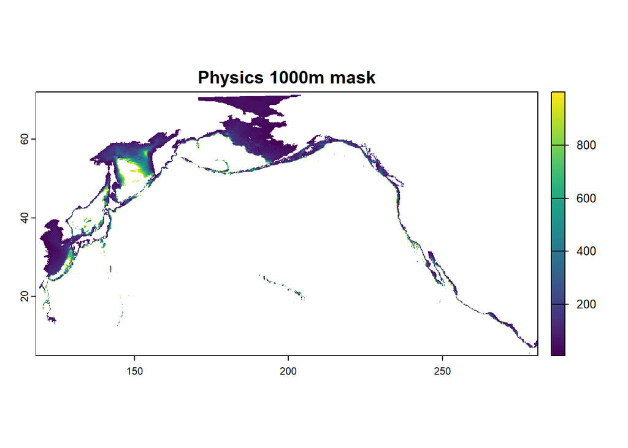

```r
mask1k_phys<- rast(here('data','spatial','GLORYS_phys_1000m_mask.tif'))
plot(mask1k_phys,main="Physics 1000m mask")
```

Here’s a basic map of each zone. The following analyses are performed on the scale of these zones.

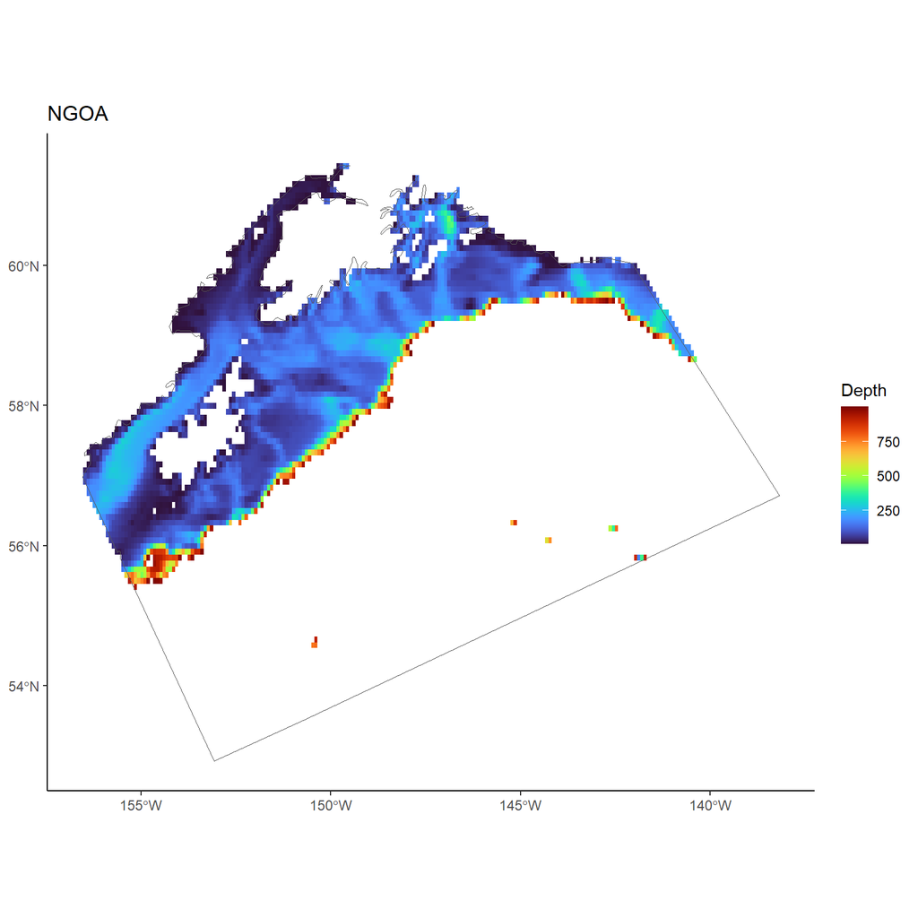

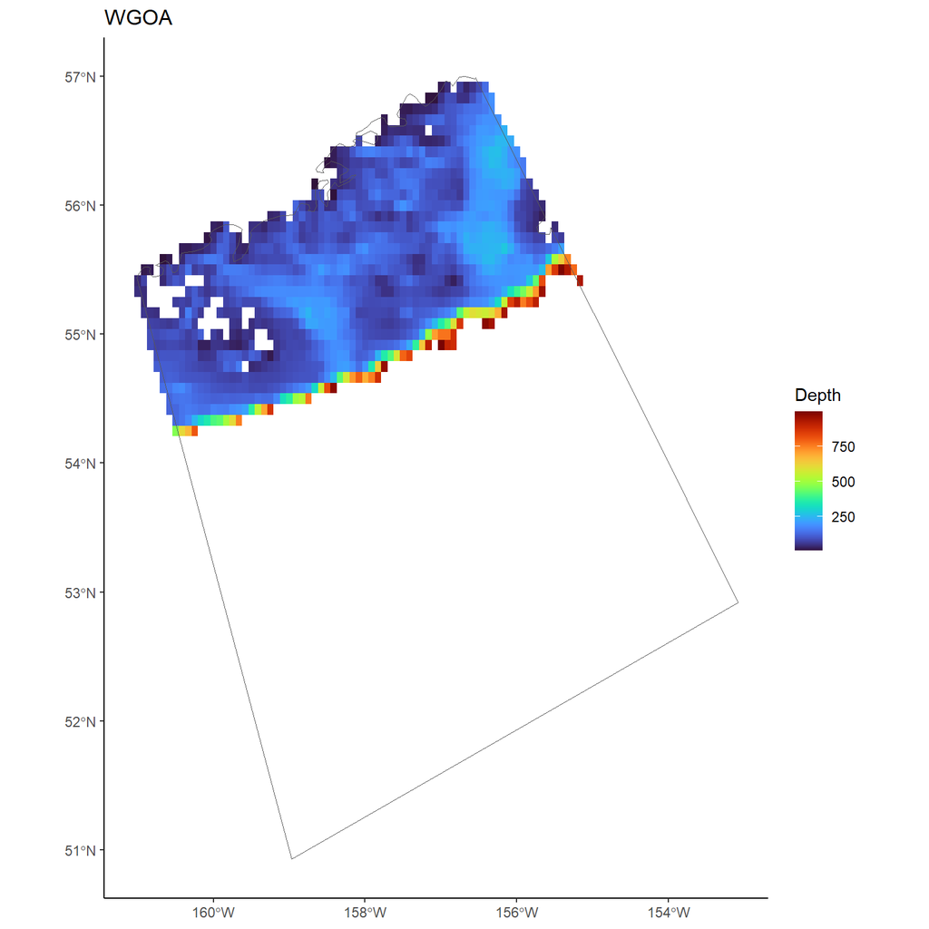

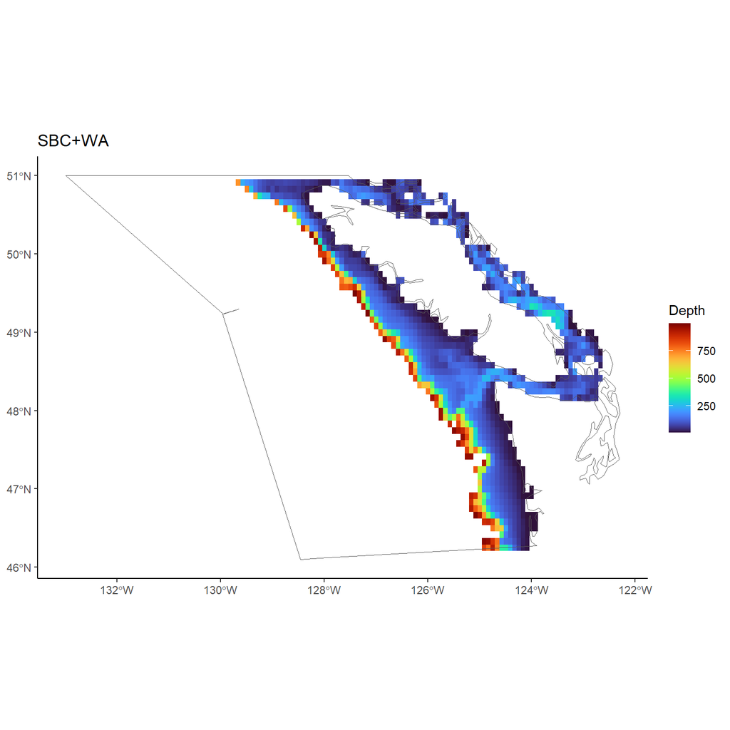

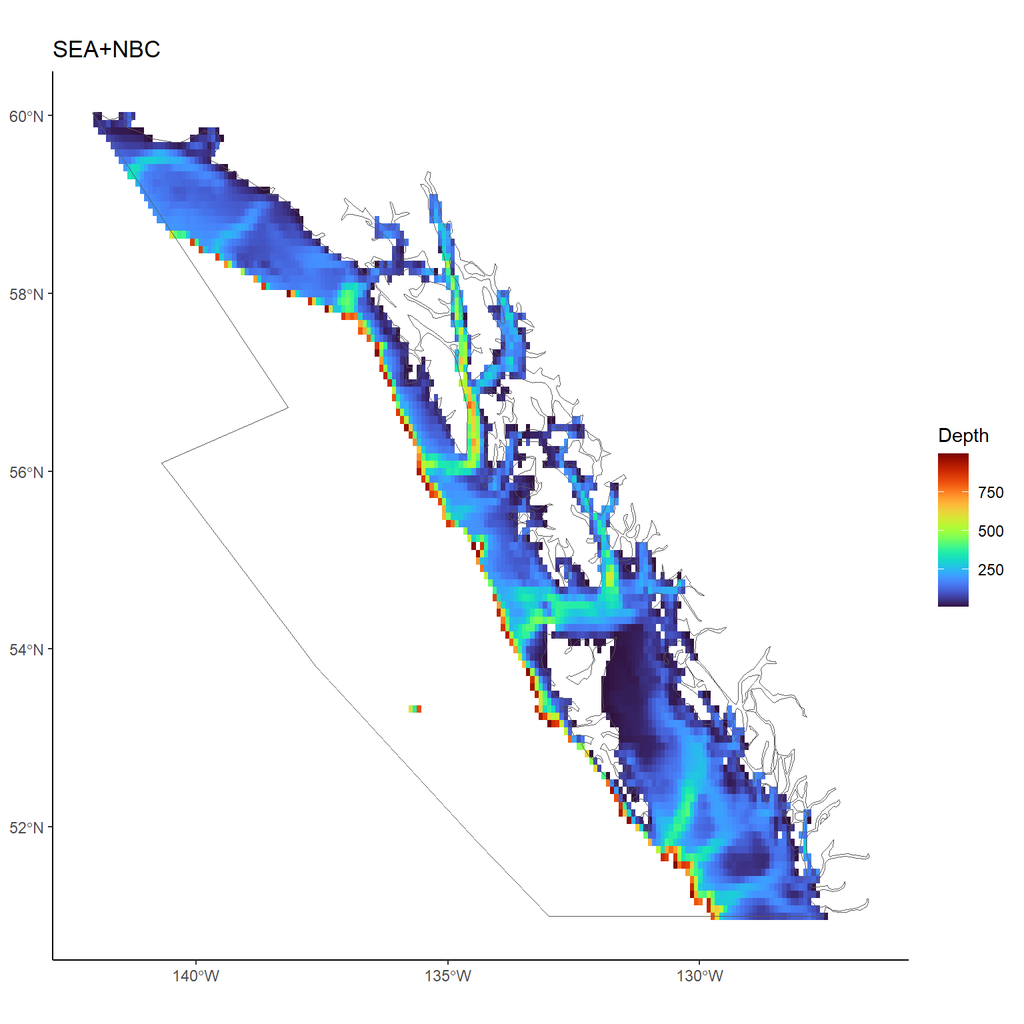

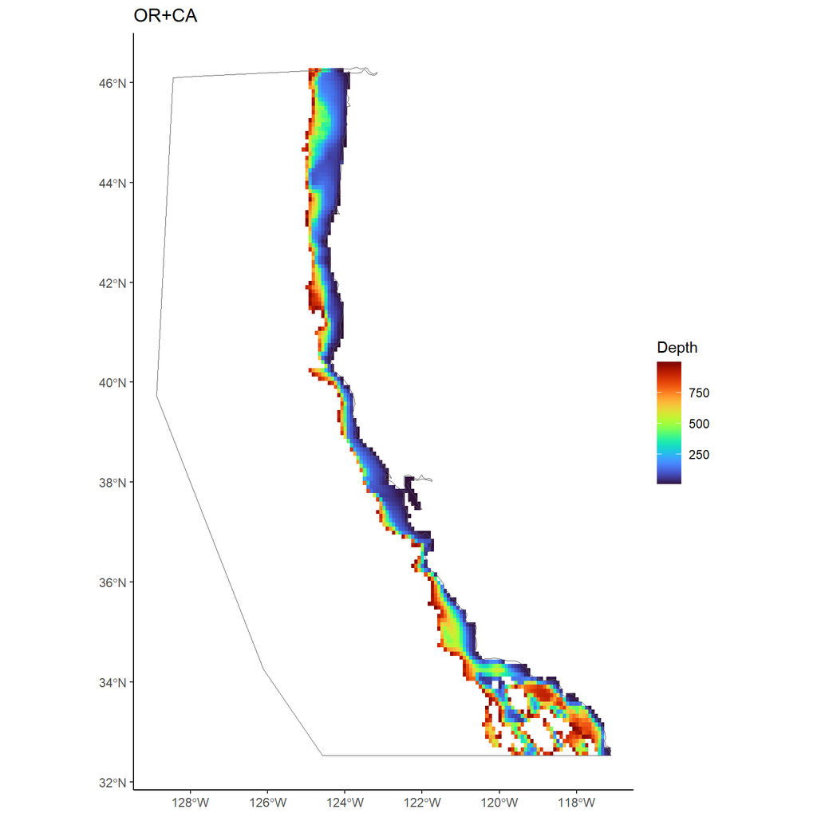

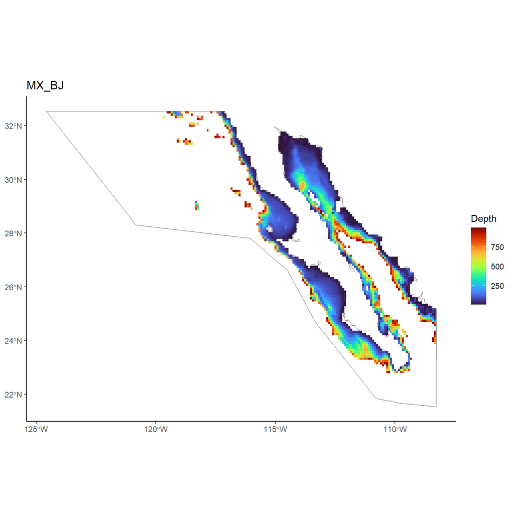

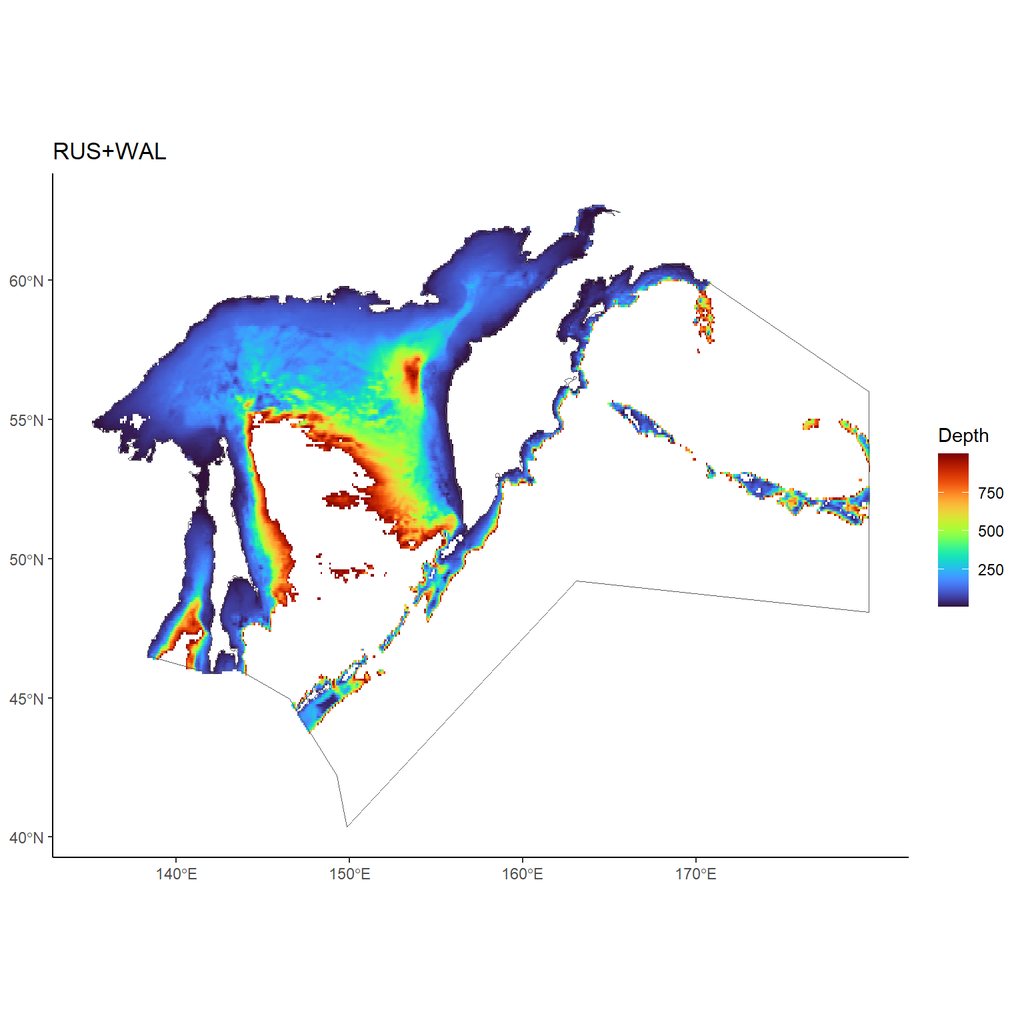

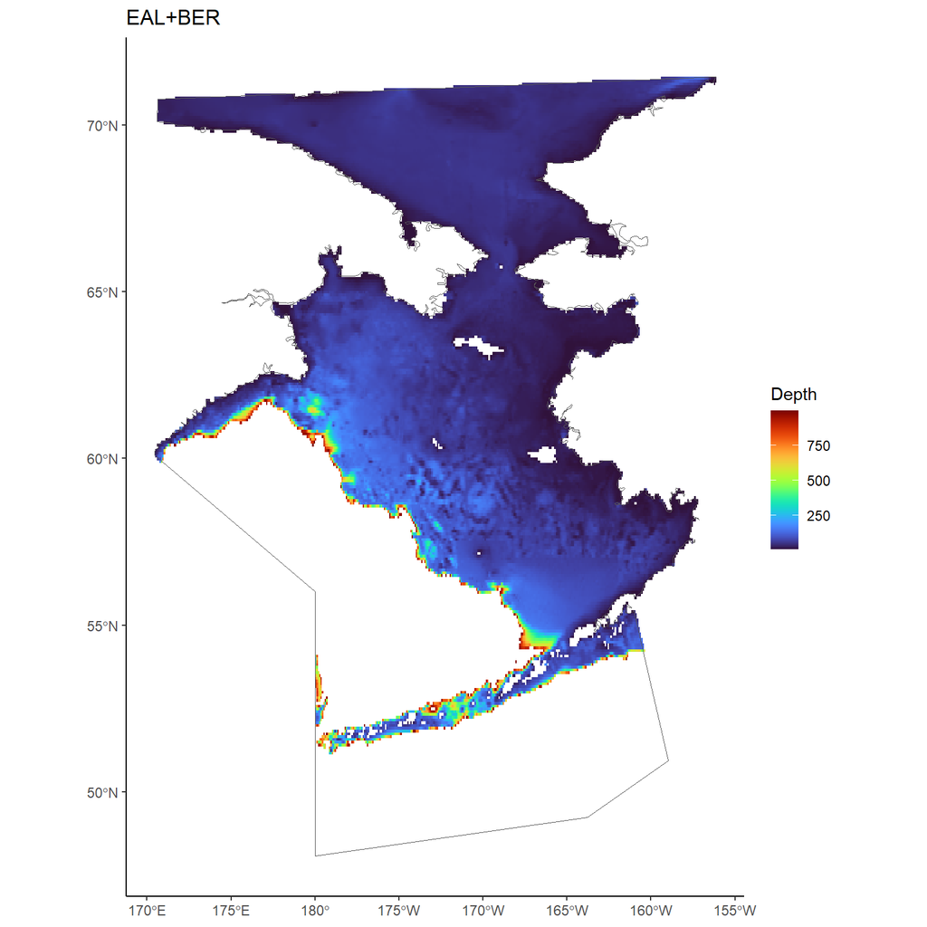

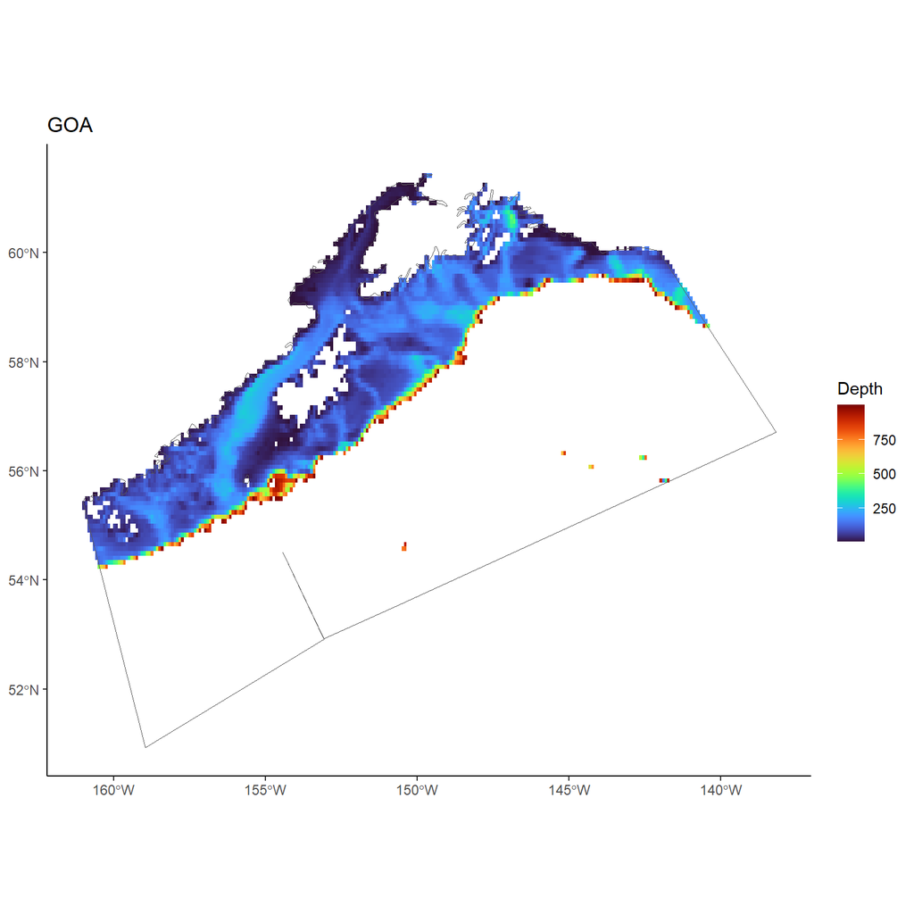

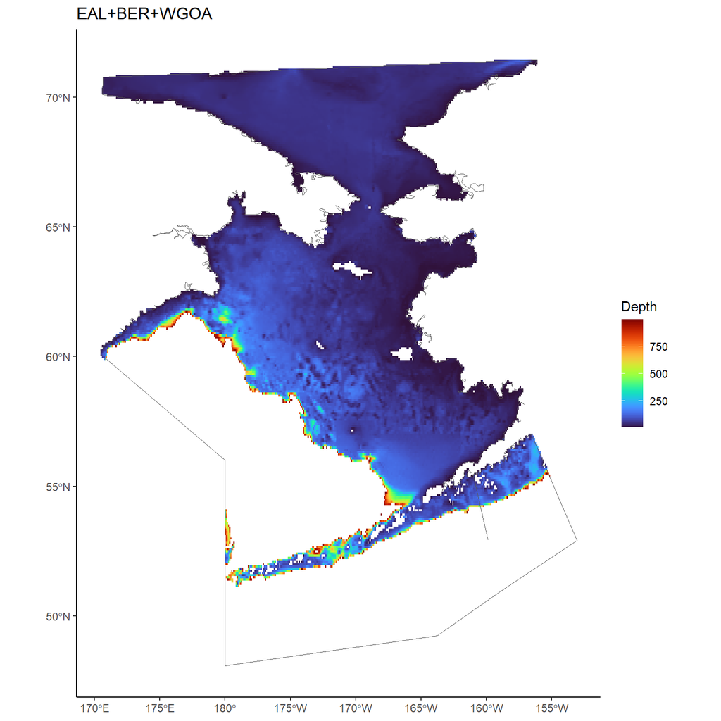

```r
zones_p <- map(fzones$Name,\(x){
  v <- filter(fzones,Name==x)
  b <- crop(mask1k_phys,v) |> mask(v)
  p <- ggplot()+
    geom_spatraster(data=b,aes(fill=deptho))+
    geom_sf(data=v,fill=NA)+
    scale_fill_viridis(option='turbo',na.value=NA)+
    labs(fill="Depth",title=x)
  p
})
walk(zones_p,plot)
```

### GLORYS

The GLORYS files have already been subsetted to the different feeding grounds.

```r
glorys.fls <- list.files(here('data','glorys','phys','raw'),full.names = T) |>
  str_subset("statics",negate=T)

# use the nc files to find the timestamps
glorys_times1 <- tidync(glorys.fls[1]) |> hyper_transforms() |> pluck('time') |> pull('timestamp')
glorys_times2 <- tidync(glorys.fls[2]) |> hyper_transforms() |> pluck('time') |> pull('timestamp')
glorys_times <- c(glorys_times1,glorys_times2) |> as_date()
```

### MOM6

The MOM6 data are in a single .nc file downloaded from the online portal.

```r
mom6.fl <- list.files(here('data','mom6','raw'),full.names = T)

# get times for mom6. we'll attach these to the regridded data below
mom6_times <- tidync(mom6.fl) |> hyper_transforms() |> pluck('time') |> pull('timestamp') |>
  as_date()
mom6.ym <- ym(paste(year(mom6_times),month(mom6_times),sep="_"))
```

### GHRSST

The GHRSST data have been downloaded as monthly rasters (not yet spatially subsetted by zone)

```r
ghrsst.fls <- list.files(here('data','podaac'),full.names=T) |> str_subset(".tif")
ghrsst.m <- str_split_i(ghrsst.fls,"_",6) |> str_remove_all(".tif") # extract month from file name
ghrsst.y <- str_split_i(ghrsst.fls,"_",5) # extract year from file name
ghrsst.ym <- ym(paste(ghrsst.y,ghrsst.m,sep="_")) # create dates
ghrsst.fl.sort <- ghrsst.fls[match(sort(ghrsst.ym),ghrsst.ym)] # sort file names in date order

# import the raster in the right date order and add the times
ghrsst.rast <- rast(ghrsst.fl.sort)
time(ghrsst.rast) <- sort(ghrsst.ym)
```

## Regrid

In order to compare MOM6 (which is run on a curvilinear grid) to the other sources (which are on a linear grid), we need to regrid the MOM6 file to the same CRS and and resolution as the GLORYS grid. We do this with the GDAL utility `warp`, using cubic interpolation to a linear grid with the same resolution as GLORYS.

### MOM6

```r
regrid.dir <- here('data','mom6','regrid')
if(!dir.exists(regrid.dir)) dir.create(regrid.dir)

mom6.regrid.fn <- here('data','mom6','regrid','sst.regrid.nc')
```

```r
# Regridding goes from ROMS curvilinear grid to a regular, 0.1x0.1degree lat/lon grid
# Regridding is done with cubic interpolation
gdal_utils("warp",
           source=mom6.fl,
           destination = mom6.regrid.fn,
           options= c(
             "-t_srs","EPSG:4326",
             "-r","cubic",
             "-tr","0.0833333333333333", "0.0833333333333333",
             "-dstnodata","None", # try to force correct NA handling
             "-dstalpha", # this is to include a "nodata" identifier as the last band
             "-overwrite"))
```

Here’s the MOM6 raster stack regridded for further analysis

```r
mom6.rast <- rast(mom6.regrid.fn)
```

Plot a time slice

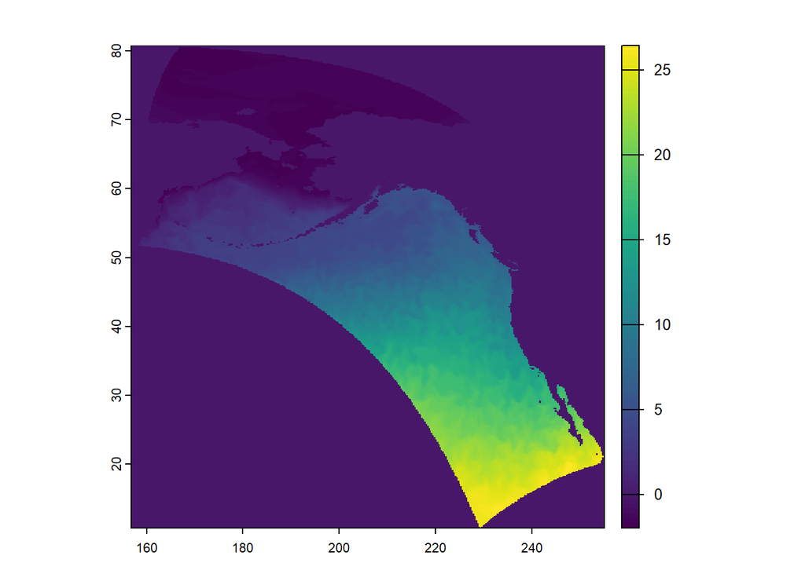

```r
plot(mom6.rast[[1]])
```

### Check NA Handling

We need NAs to be encoded with `NA`, which the warping utility may not have done. But we can check because we included a “nodata” band in the file, which identifies the cells that should be NA.

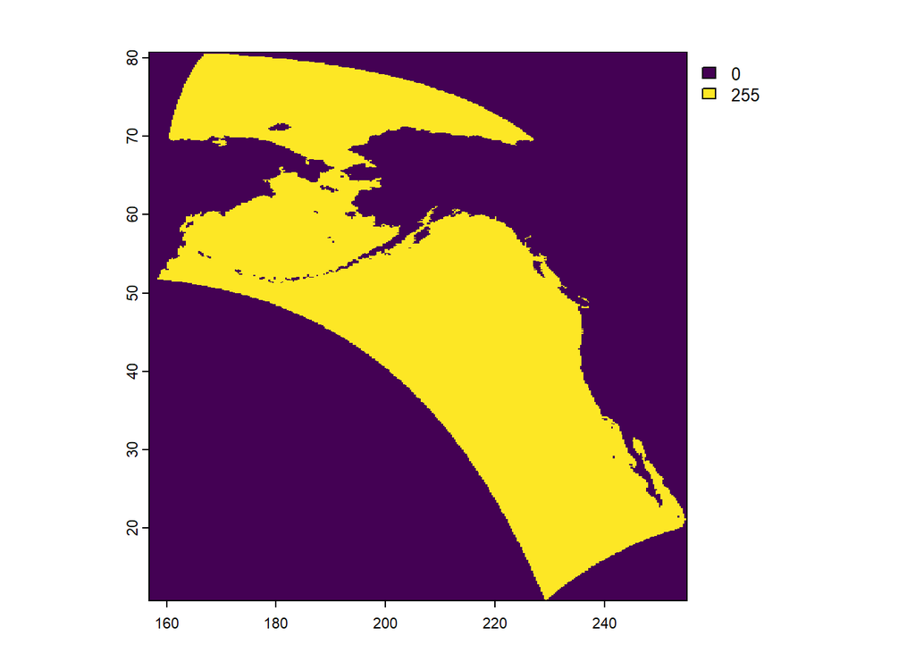

```r
# cells that the warping algorithm identified as nodata
mom6mask <- subset(mom6.rast,nlyr(mom6.rast))
plot(mom6mask)
```

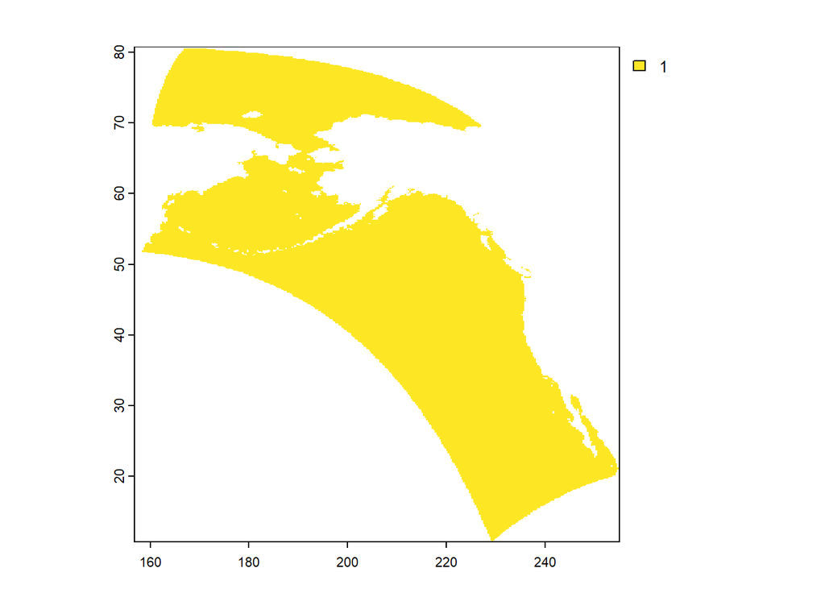

```r
#instead of 255 or 0, how about 1 and NA
mom6mask <- mom6mask |>
  subst(0,NA) |> #replace 0 with NA
  subst(255,1) #replace 255 with 1
plot(mom6mask)
```

Use this NA mask to make sure the NAs are properly designated.

```r
mom6.rast <- mom6.rast |>
  mask(mom6mask) # takes a second to mask all the layers
```

```
|---------|---------|---------|---------|
=========================================
```

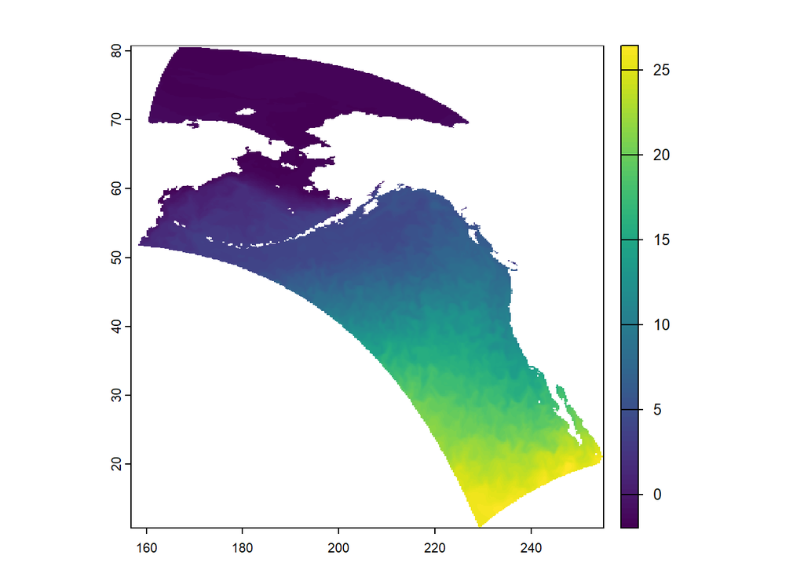

```r
# and remove the mask as a layer
mom6.nlyr <- nlyr(mom6.rast)
mom6.rast <- subset(mom6.rast,c(0:(mom6.nlyr-1)))

# and plot again
plot(mom6.rast[[1]])
```

This looks better.

```r
# add the right timesteps
time(mom6.rast) <- mom6.ym
```

## Compare

### Time Subset

What time range of months do we have for each dataset?

```r
setdiff(time(mom6.rast),glorys_times) # these are the same (Jan 1993 - Dec 2024)
```

```
Date of length 0
```

```r
setdiff(time(mom6.rast),time(ghrsst.rast)) # GHRSST starts in September, 2002
```

```
  [1] "1993-01-01" "1993-02-01" "1993-03-01" "1993-04-01" "1993-05-01"
  [6] "1993-06-01" "1993-07-01" "1993-08-01" "1993-09-01" "1993-10-01"
 [11] "1993-11-01" "1993-12-01" "1994-01-01" "1994-02-01" "1994-03-01"
 [16] "1994-04-01" "1994-05-01" "1994-06-01" "1994-07-01" "1994-08-01"
 [21] "1994-09-01" "1994-10-01" "1994-11-01" "1994-12-01" "1995-01-01"
 [26] "1995-02-01" "1995-03-01" "1995-04-01" "1995-05-01" "1995-06-01"
 [31] "1995-07-01" "1995-08-01" "1995-09-01" "1995-10-01" "1995-11-01"
 [36] "1995-12-01" "1996-01-01" "1996-02-01" "1996-03-01" "1996-04-01"
 [41] "1996-05-01" "1996-06-01" "1996-07-01" "1996-08-01" "1996-09-01"
 [46] "1996-10-01" "1996-11-01" "1996-12-01" "1997-01-01" "1997-02-01"
 [51] "1997-03-01" "1997-04-01" "1997-05-01" "1997-06-01" "1997-07-01"
 [56] "1997-08-01" "1997-09-01" "1997-10-01" "1997-11-01" "1997-12-01"
 [61] "1998-01-01" "1998-02-01" "1998-03-01" "1998-04-01" "1998-05-01"
 [66] "1998-06-01" "1998-07-01" "1998-08-01" "1998-09-01" "1998-10-01"
 [71] "1998-11-01" "1998-12-01" "1999-01-01" "1999-02-01" "1999-03-01"
 [76] "1999-04-01" "1999-05-01" "1999-06-01" "1999-07-01" "1999-08-01"
 [81] "1999-09-01" "1999-10-01" "1999-11-01" "1999-12-01" "2000-01-01"
 [86] "2000-02-01" "2000-03-01" "2000-04-01" "2000-05-01" "2000-06-01"
 [91] "2000-07-01" "2000-08-01" "2000-09-01" "2000-10-01" "2000-11-01"
 [96] "2000-12-01" "2001-01-01" "2001-02-01" "2001-03-01" "2001-04-01"
[101] "2001-05-01" "2001-06-01" "2001-07-01" "2001-08-01" "2001-09-01"
[106] "2001-10-01" "2001-11-01" "2001-12-01" "2002-01-01" "2002-02-01"
[111] "2002-03-01" "2002-04-01" "2002-05-01" "2002-06-01" "2002-07-01"
[116] "2002-08-01"
```

```r
# GHRSST is the limiting dataset for time series
# Designate which GLORYS and MOM6 layers to use to make a consistent timeseries
which_glorys_times <- which(glorys_times%in%time(ghrsst.rast))
which_mom6_times <- which(time(mom6.rast)%in% time(ghrsst.rast))

# time lookup table that links raster layer numbers to year/months
timetbl <- tibble(date=time(ghrsst.rast),year=year(date),month=month(date)) |>
  mutate(ind=row_number())
```

### Spatial Subset

MOM6 does not cover the northwest Pacific; which feeding zones can we apply the comparison to? Find which feeding zones are covered by MOM6.

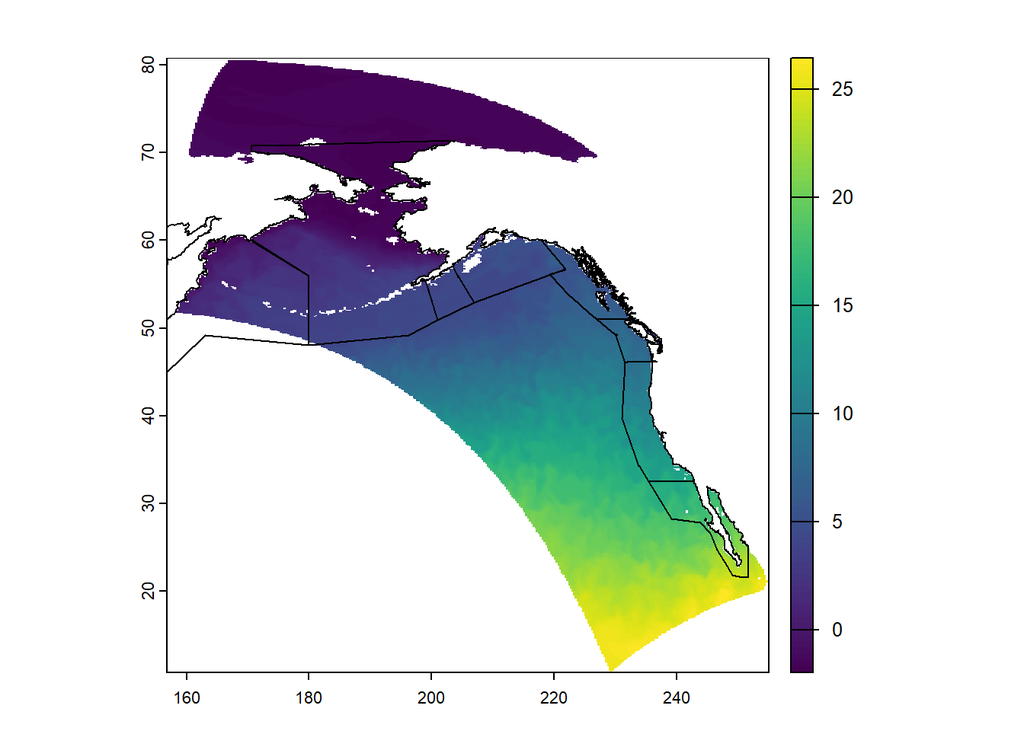

```r
plot(mom6.rast[[1]]);polys(fzonesv)
```

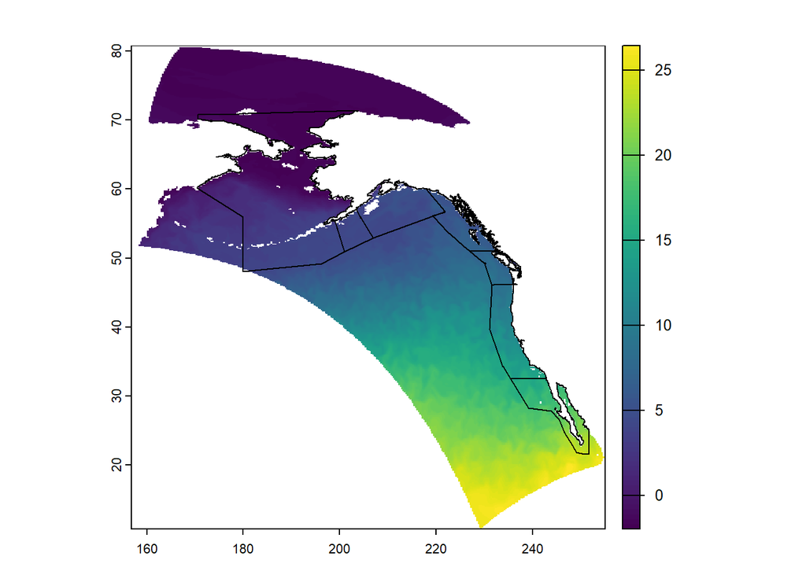

```r
fzones_sub <- fzonesv[is.related(fzonesv,ext(mom6.rast),"within")] # we only lose RUS+WAL
plot(mom6.rast[[1]]);polys(fzones_sub)
```

We actually only lose 1 feeding ground (Russia and W. Aleutians)

### Feeding Zone Rasters

Make a raster for each feeding zone with 3 sub-datasets, one from each SST source. The rasters will all have identical extents, resolutions, and time steps. Specifically, we use bilinear interpolation to resample GHRSST and MOM6 to the GLORYS geometry. We crop and mask the output layers using our bathymetry mask from above, as well as the shapefile of feeding zones, in order to “mask out” (i.e., set to `NA`) any grid cells that we do not want to include in our correlation and anomaly calculations.

```r
# for a given zone, make a raster dataset
make_sst_r_3source <- function(z){
  # get GLORYS (data is in two chunks, which we combine and then filter for the right times)
  glfn <- glorys.fls |> str_subset(str_escape(z)) # find the right files
  glr1 <- rast(glfn[1],subds="thetao")
  glr2 <- rast(glfn[2],subds='thetao')
  glr <- c(glr1,glr2) |> subset(which_glorys_times) # filter time
  if(any(as.vector(ext(glr))<0)) glr <- rotate(glr) # rotate longitude if needed
  names(glr) <- rep("glorys.sst",nlyr(glr))

  # get GHRSST, crop to GLORYS zone, and resample
  ghrsstr <- ghrsst.rast |>
    crop(glr) |> # crop to GLORYS extent
    resample(glr,method='bilinear') |> # resample to GLORYS grid geometry using bilinear interpolation
    mask(glr) # mask out cells that are NA in GLORYS
  ghrsstr <- ghrsstr-273 # convert SKelvin to C
  names(ghrsstr) <- rep("ghrsst",nlyr(ghrsstr))

  # get MOM6, crop, and resample
  mom6r <- mom6.rast |>
    subset(which_mom6_times) |> #filter time
    crop(glr) |> # crop to GLORYS extent
    resample(glr,method='bilinear') |>
    mask(glr)
  names(mom6r) <- rep("mom6.sst",nlyr(mom6r))

  # join
  srds <- sds(glr,ghrsstr,mom6r)

  # do a final trim using the bathymetry mask and the zone polygon
  # this masks out areas > 1000m depth
  zv <- fzones_sub %>% subset(fzones_sub$zoneID==z)
  rmask <- mask1k_phys |> crop(zv) |> mask(zv)
  srds <- srds |>
    lapply(crop,y=rmask) |>
    lapply(mask,mask=rmask) |> sds()

  # name the sub-datasets
  names(srds) <- c("GLORYS","GHRSST","MOM6")

  srds
}
```

Test the function, e.g. for the NGOA (Northern Gulf of Alaska) feeding zone.

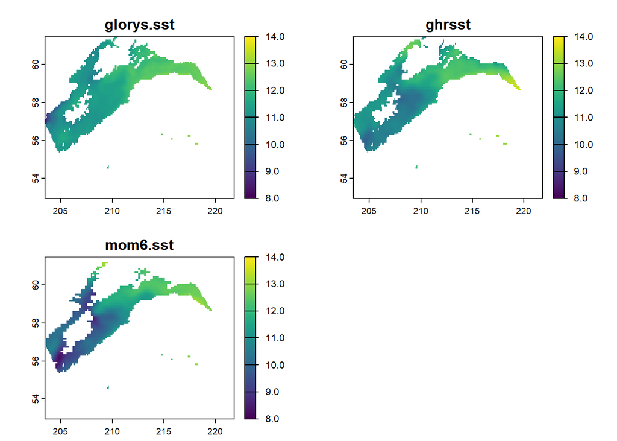

```r
test <- make_sst_r_3source("NGOA_8")

# first time slice
test_slice <- c(test$GLORYS[[1]],test$GHRSST[[1]],test$MOM6[[1]])
plot(test_slice,range=c(8,14))
```

Now let’s make the raster datasets for all the feeding zones.

```r
# Make the raster dataset for each feeding zone
zones_datasets <- map(fzones_sub$zoneID, make_sst_r_3source) |>
  set_names(str_replace_all(fzones_sub$Name,"\\+","_")) # set names for the list of zones

# a factor for plotting the zones from Northwest -> Southeast
zones_ord <- tibble(zone=names(zones_datasets),zone_ord=factor(zone,levels=c("EAL_BER","WGOA","EAL_BER_WGOA","NGOA","GOA","SEA_NBC","SBC_WA","OR_CA","MX_BJ")))
```

To plot an individual month

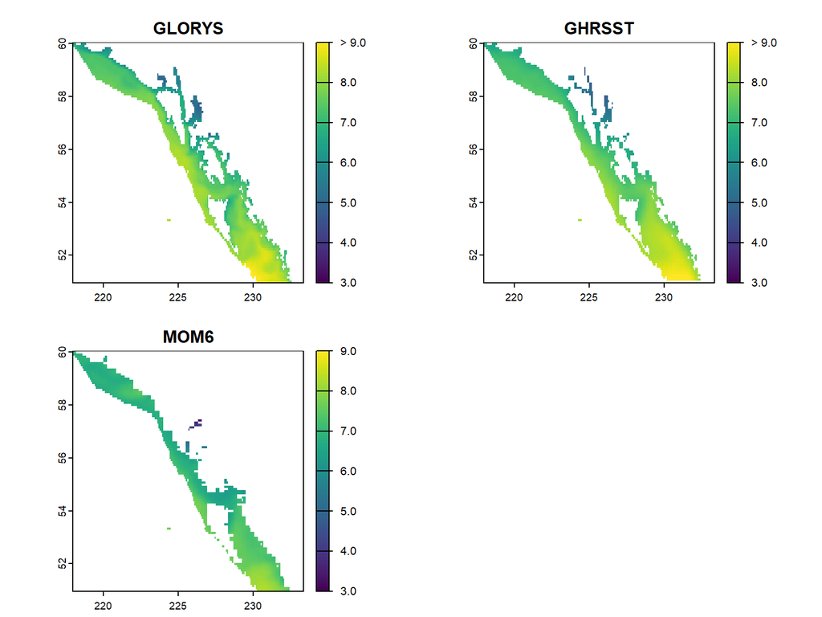

```r
compare_month <- function(dat,y,m){
  lyrind <- timetbl |> filter(year==y,m==month) |> pull(ind)
  subdat <- map(dat,subset,subset=lyrind) |> rast()
  plot(subdat,range=round(range(minmax(subdat))),fill_range=T)
}
compare_month(zones_datasets$SEA_NBC,y=2003,m=12)
```

### Correlation

Using the dataset we created above, we can compute the Pearson correlation between the 3 pairs of SST sources for each time step.

A function to calculate the correlation between the 3 SST sources, using `terra::layerCor`.

```r
make_cor_month <- function(dat,tind){ #for a given dataset and time index
  # pull out the right time step from each source
  r <- dat |> lapply(\(k)subset(k,subset=tind)) |>
    # make into a raster, where the raster layers are the 3 sources
    rast()
  # calculate the correlation between the 3 layers
  out <- layerCor(r,fun="cor") |>
    # pluck the correlation matrix from the resultS
    pluck('correlation')
  # make into a longform dataframe
  outlong <- out |> as_tibble() |>
    mutate(Var1=rownames(out)) |>
    pivot_longer(cols=-Var1,names_to="Var2",values_to="correlation")
  outlong |> mutate(ind=tind)
}
```

```r
# This takes a few minutes to run
dataset_cor_ts <- map(zones_datasets,\(x){
  map(timetbl$ind,\(tind){ # for each time slice, calculate cor
    make_cor_month(x,tind)
  }) |>
    list_rbind()
},.progress = T)
```

We can now make a correlation time series

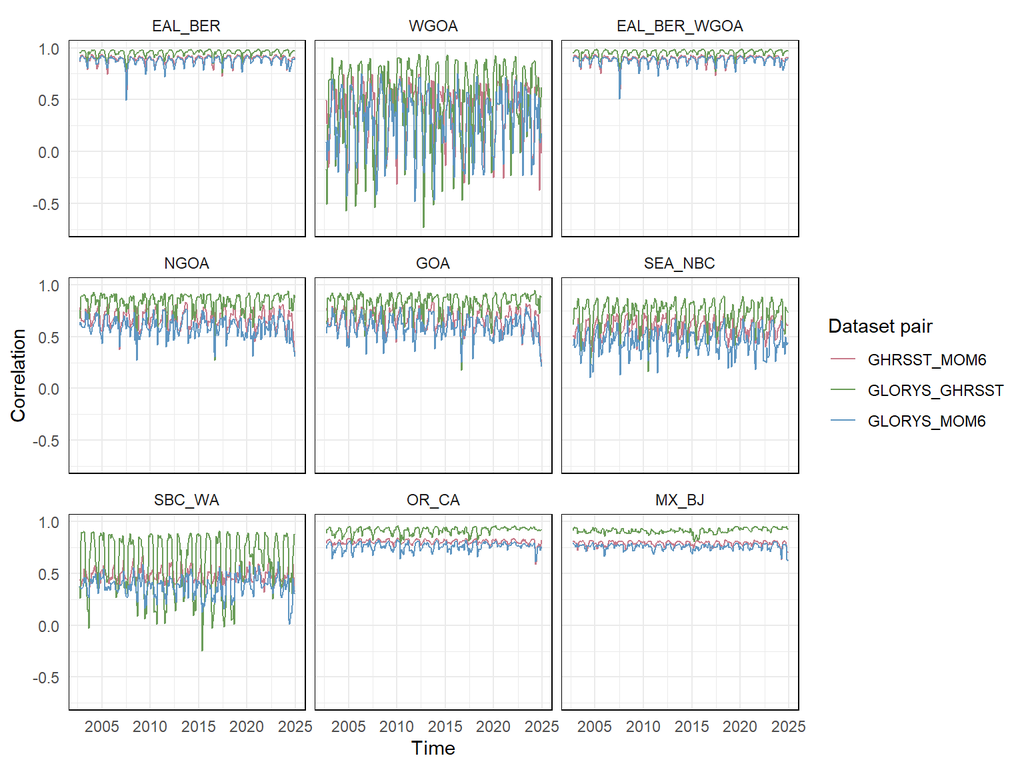

```r
dataset_cor_df <- map2(dataset_cor_ts,names(dataset_cor_ts),\(x,y) mutate(x,zone=y)) |>
  list_rbind() |>
  # zones as factor for plotting order
  left_join(zones_ord,by=join_by(zone)) |>
  # remove correlations with themselves
  filter(correlation<1) |>
  # identifier for pair
  unite(pair,Var1,Var2,remove=F) |>
  # remove extras again (because correlation is symmetrical)
  filter(pair %in% c("GLORYS_GHRSST","GLORYS_MOM6","GHRSST_MOM6")) |>
  left_join(timetbl,by=join_by(ind))

dataset_cor_ts_p <- dataset_cor_df |>
  ggplot(aes(date,correlation,col=pair))+
  geom_line()+
  scale_color_manual(values=qualitative_hcl(palette="Dark 2",n=3))+
  facet_wrap(~zone_ord)+
  labs(x="Time",y="Correlation",color="Dataset pair")+
  theme_minimal()+
  theme(panel.border = element_rect(fill=NA,color='black'))
dataset_cor_ts_p
```

This looks like it has a seasonal pattern. Calculate average correlation by month.

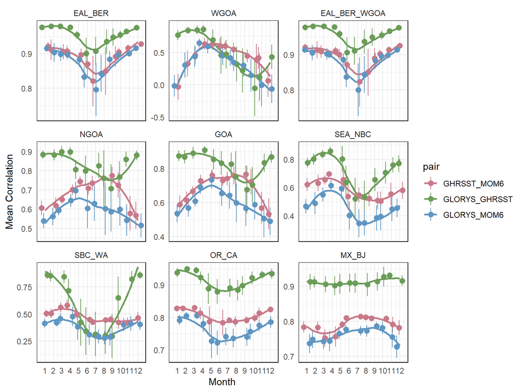

```r
dataset_cor_df_month <- dataset_cor_df |>
  group_by(month,zone_ord,pair) |>
  summarise(cor.mean=mean(correlation),
            cor.sd=sd(correlation),.groups = "drop") |>
  mutate(upper=cor.mean+cor.sd,
         lower=cor.mean-cor.sd)
dataset_cor_ts_p2 <- dataset_cor_df_month |>
  ggplot(aes(month,cor.mean,color=pair))+
  geom_smooth(se=F)+
  geom_pointrange(aes(ymax=upper,ymin=lower),position = position_jitter())+
  scale_color_manual(values=qualitative_hcl(palette="Dark 2",n=3))+
  labs(y="Mean Correlation",x="Month")+
  facet_wrap(~zone_ord,scales='free_y')+
  scale_x_continuous(breaks=seq(1,12,by=1))+
  theme_minimal()+
  theme(panel.border = element_rect(fill=NA,color='black'))
dataset_cor_ts_p2
```

### Mean Difference

We can also look at how the datasets are “biased” compared to one another by computing the mean differences between them.

```r
make_dif_month <- function(dat,tind){
  # pull timestep from each dataset, recombine into a layered raster
  r <- dat |> lapply(\(k) subset(k,subset=tind)) |> rast()

  # make the difference rasters
  glorys_ghrsst <- r[["GLORYS"]]-r[["GHRSST"]]
  glorys_mom6 <- r[["GLORYS"]]-r[["MOM6"]]
  ghrsst_mom6 <- r[["GHRSST"]]-r[["MOM6"]]

  # calc mean differences
  dif1 <- global(glorys_ghrsst,'mean',na.rm=T) |> as.numeric()
  dif2 <- global(glorys_mom6,'mean',na.rm=T) |> as.numeric()
  dif3 <- global(ghrsst_mom6,'mean',na.rm=T) |> as.numeric()

  sd1 <- global(glorys_ghrsst,'sd',na.rm=T) |> as.numeric()
  sd2 <- global(glorys_mom6,'sd',na.rm=T) |> as.numeric()
  sd3 <- global(ghrsst_mom6,'sd',na.rm=T) |> as.numeric()

  # out
  tibble(pair=c("GLORYS_GHRSST","GLORYS_MOM6","GHRSST_MOM6"),
         meandiff=c(dif1,dif2,dif3),
         sddiff =c(sd1,sd2,sd3),
         ind=tind)

}
```

```r
dataset_dif_ts <- map(zones_datasets,\(x){
  map(timetbl$ind,\(tind){ # for each time slice, calculate diff
    make_dif_month(x,tind)
  }) |>
    list_rbind()#row bind everything
},.progress = T)# takes about 5m to run
```

Make a timeseries

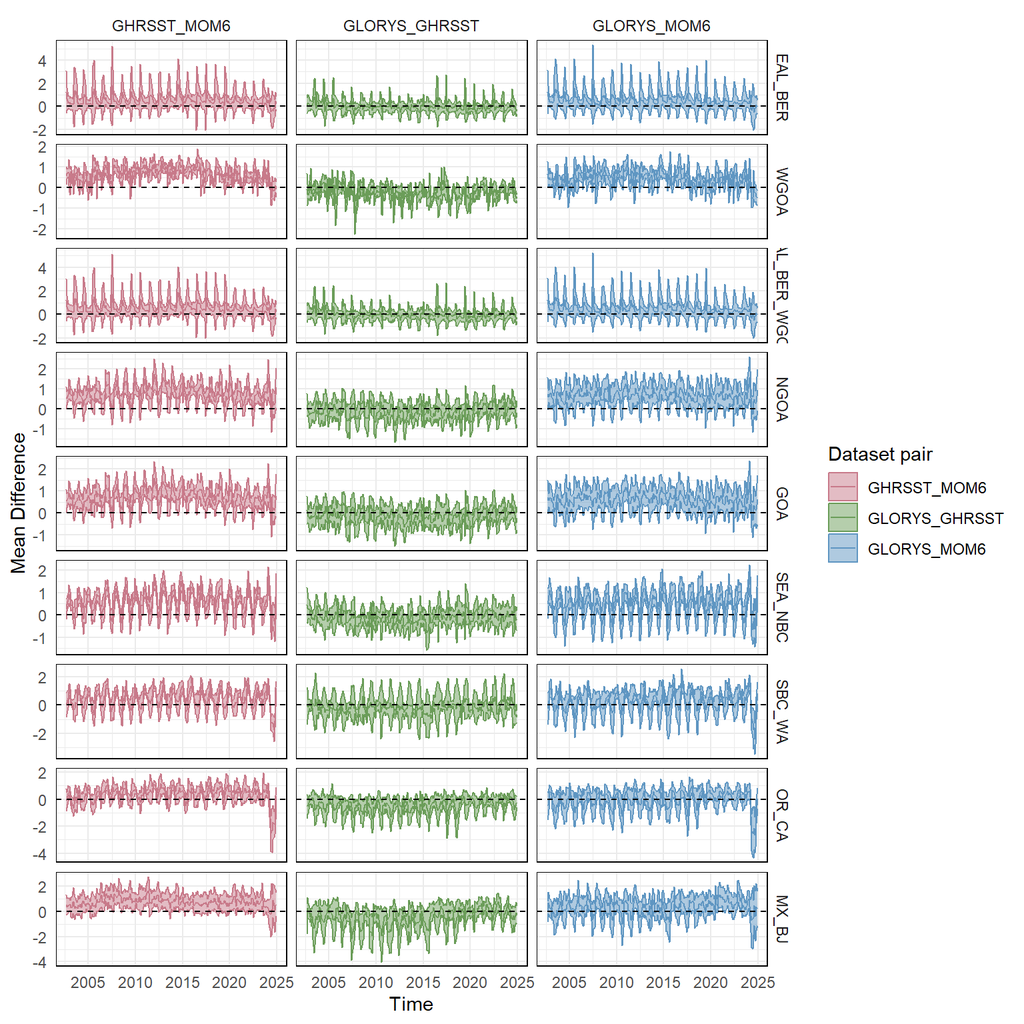

```r
dataset_dif_df <- map2(dataset_dif_ts,names(dataset_dif_ts),\(x,y) mutate(x,zone=y)) |>
  list_rbind() |>
  left_join(timetbl,by=join_by(ind)) |>
  # zones as factor for plotting order
  left_join(zones_ord,by=join_by(zone))

dataset_dif_ts_p <- dataset_dif_df |>
  ggplot(aes(date,meandiff,col=pair,fill=pair))+
  geom_line()+
  geom_ribbon(aes(ymax=meandiff+sddiff,ymin=meandiff-sddiff),alpha=0.5)+
  scale_color_manual(values=qualitative_hcl(palette="Dark 2",n=3))+
  scale_fill_manual(values=qualitative_hcl(palette="Dark 2",n=3))+
  geom_hline(yintercept=0,linetype=2)+
  facet_grid(zone_ord~pair,scales='free_y')+
  labs(x="Time",y="Mean Difference",color="Dataset pair",fill="Dataset pair")+
  theme_minimal()+
  theme(panel.border = element_rect(fill=NA,color='black'))
dataset_dif_ts_p
```

We definitely see a seasonal pattern here as well.

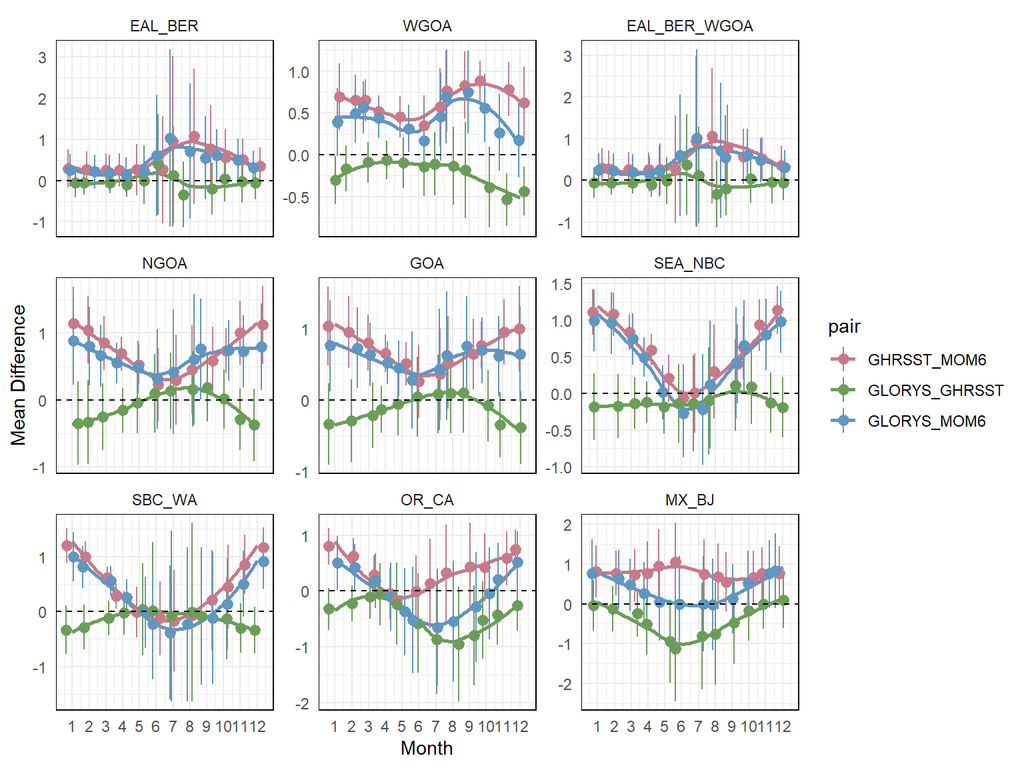

```r
dataset_dif_df_month <- dataset_dif_df |>
  group_by(month,zone_ord,pair) |>
  summarise(dif.mean=mean(meandiff),
            dif.sd=mean(sddiff),.groups = "drop") |>
  mutate(upper=dif.mean+dif.sd,
         lower=dif.mean-dif.sd)
dataset_dif_ts_p2 <- dataset_dif_df_month |>
  ggplot(aes(month,dif.mean,color=pair))+
  geom_smooth(se=F)+
  geom_pointrange(aes(ymax=upper,ymin=lower),position = position_jitter())+
  scale_color_manual(values=qualitative_hcl(palette="Dark 2",n=3))+
  labs(y="Mean Difference",x="Month")+
  facet_wrap(~zone_ord,scales='free_y')+
  scale_x_continuous(breaks=seq(1,12,by=1))+
  geom_hline(yintercept = 0,linetype=2)+
  theme_minimal()+
  theme(panel.border = element_rect(fill=NA,color='black'))
dataset_dif_ts_p2
```

What about an annual trend?

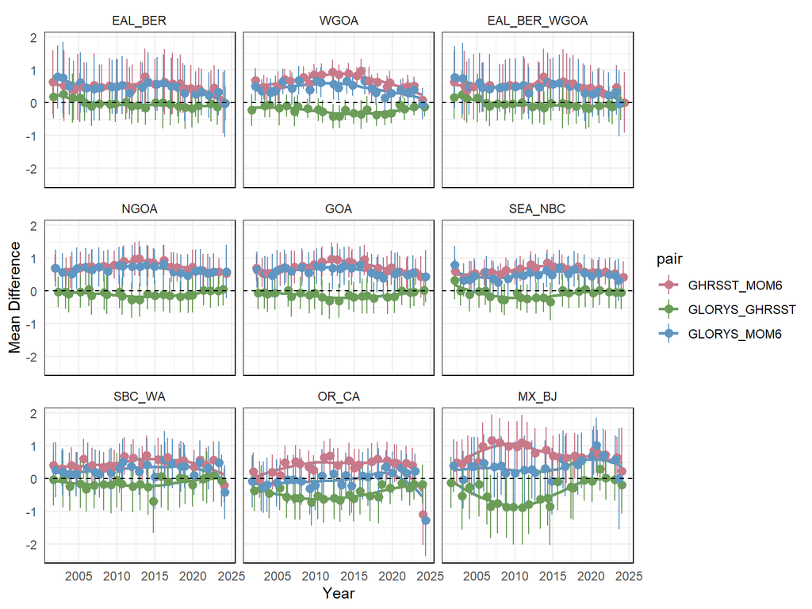

```r
dataset_dif_df_yr <- dataset_dif_df |>
  group_by(year,zone_ord,pair) |>
  summarise(dif.mean=mean(meandiff),
            dif.sd=mean(sddiff),.groups = "drop") |>
  mutate(upper=dif.mean+dif.sd,
         lower=dif.mean-dif.sd)
dataset_dif_ts_p3 <- dataset_dif_df_yr |>
  ggplot(aes(year,dif.mean,color=pair))+
  geom_smooth(se=F)+
  geom_pointrange(aes(ymax=upper,ymin=lower),position = position_jitter())+
  scale_color_manual(values=qualitative_hcl(palette="Dark 2",n=3))+
  labs(y="Mean Difference",x="Year")+
  facet_wrap(~zone_ord)+
  geom_hline(yintercept = 0,linetype=2)+
  theme_minimal()+
  theme(panel.border = element_rect(fill=NA,color='black'))
dataset_dif_ts_p3
```

### Monthly Climatologies

Now that we’ve aligned all of our data for 3 SST sources across the different feeding zones, we can define a monthly climatology, which will also give us the ability to calculate anomaly rasters.

```r
# Make monthly means (i.e., a monthly climatology) for all zones, for each dataset
zones_monthly_means <- map(zones_datasets,\(d){
  lapply(d,tapp,index="months",fun=mean) |> sds()
})
```

Here’s an example monthly climatology for the GLORYS dataset in the Northern Gulf of Alaska.

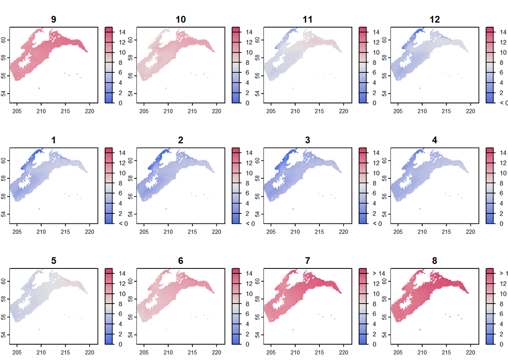

```r
paldiv <- diverging_hcl(n = 50,palette = "Blue Red 2")
zones_monthly_means$NGOA$GLORYS |>
  plot(range=c(0,15),fill_range=T,
       col=paldiv)
```

Now average across datasets as well, for a single common climatology for each zone.

```r
zones_clim <- map(zones_monthly_means,\(d){
  app(d,fun=mean)
})
```

Here’s the same zone, now, but showing the common climatology. Compare with the GLORYS-specific climatology above

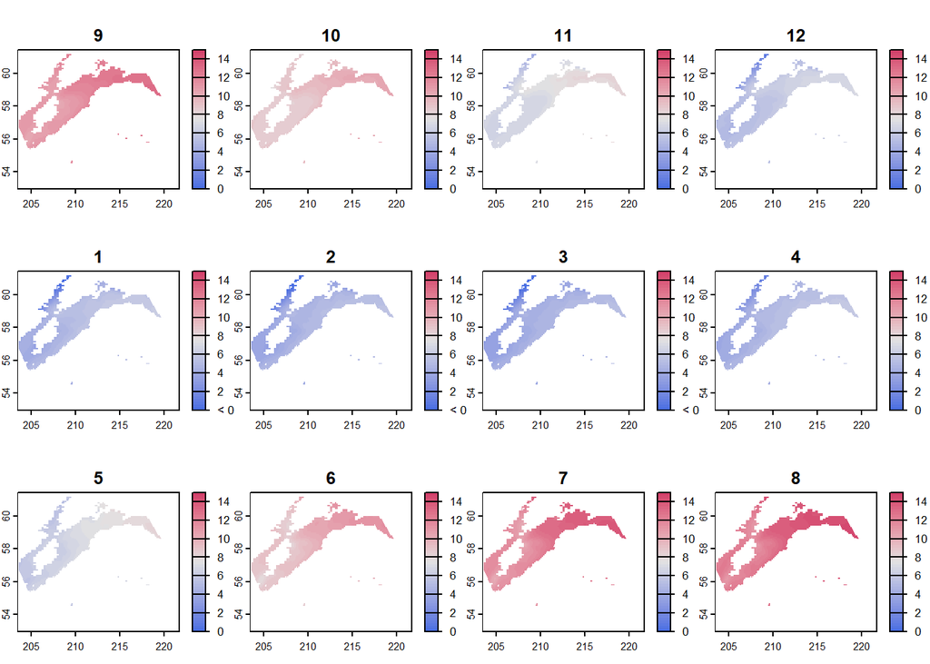

```r
zones_clim$NGOA |>
  plot(range=c(0,15),fill_range=T,
       col=paldiv)
```

### Anomaly Timeseries

We can use the climatology rasters to make a new timeseries of anomalies, defined as the observed values for each dataset, *minus* the climatology.

```r
zones_anom <- map2(zones_datasets,zones_clim,\(dat,clim){
  anom <- map(dat,\(x) x-clim) |> sds()
  anom
})
```

For a second flavor of anomaly, we can use each dataset’s own monthly climatology as the baseline.

```r
zones_anom2 <- map2(zones_datasets,zones_monthly_means,\(dat,clim){
  anom <- map2(dat,clim,\(x,y) x-y) |> sds()
  anom
})
```

Sticking with the Northern Gulf of Alaska, here is the first 12 time steps of the two versions of anomaly rasters. Remember that these are calculated by subtracting a mean monthly climatology (a common climatology or a dataset-specific climatology, respectively) from the original data.

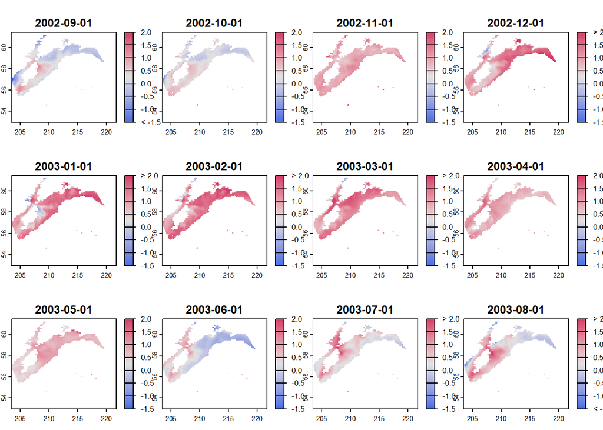

```r
plot(zones_anom$NGOA$GLORYS[[1:12]],range=c(-1.5,2),fill_range=T,col=paldiv)
```

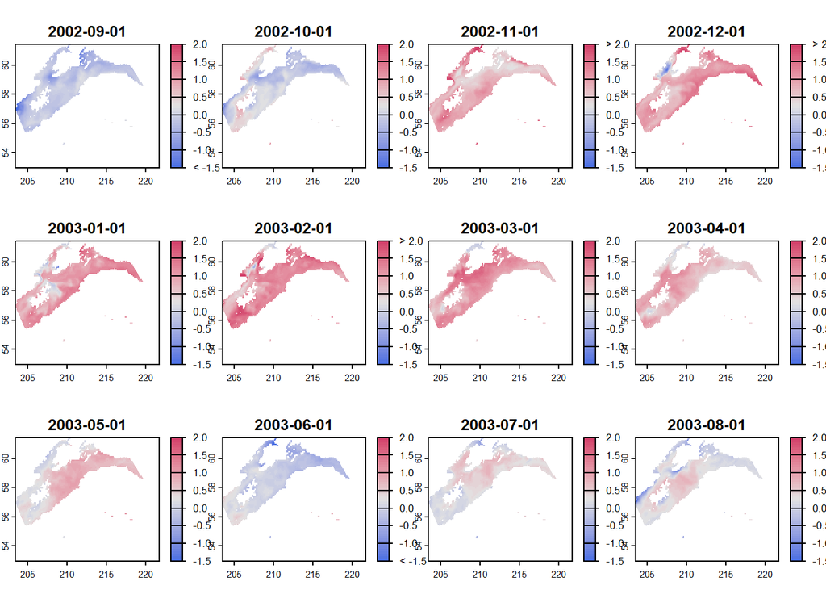

```r
plot(zones_anom2$NGOA$GLORYS[[1:12]],range=c(-1.5,2),fill_range=T,col=paldiv)
```

We can see that in this particular year (Sep 2002 to Aug 2003), GLORYS suggests that the Northern Gulf of Alaska was warmer than usual, especially in the winter and spring of 2003 (November to April).

Armed with these anomaly rasters, we can now extract some statistics, such as the mean anomaly value across all cells in each time step.

```r
mean_anom_ts <- map2(zones_anom,names(zones_anom),\(d,k) { # across zones
  ts <- map(d,\(r) global(r,fun='mean',na.rm=T)) |> # mean of each time step of each dataset
    as_tibble() |> # make into a dataframe
    mutate(across(where(is.data.frame),unlist))
  df <- timetbl |> bind_cols(as_tibble(ts)) |> mutate(zone=k) # add times and zone name
  df
})

mean_anom2_ts <- map2(zones_anom2,names(zones_anom),\(d,k) { # across zones
  ts <- map(d,\(r) global(r,fun='mean',na.rm=T)) |> # mean of each time step of each dataset
    as_tibble() |> # make into a dataframe
    mutate(across(where(is.data.frame),unlist))
  df <- timetbl |> bind_cols(as_tibble(ts)) |> mutate(zone=k) # add times and zone name
  df
})

mean_anom_df <- bind_rows(mean_anom_ts) |>
  # zones as factor for plotting order
  left_join(zones_ord,by=join_by(zone))
mean_anom2_df <- bind_rows(mean_anom2_ts) |>
  # zones as factor for plotting order
  left_join(zones_ord,by=join_by(zone))
```

### Anomaly Correlation

Overall correlation between these anomaly timeseries, by spatial zone.

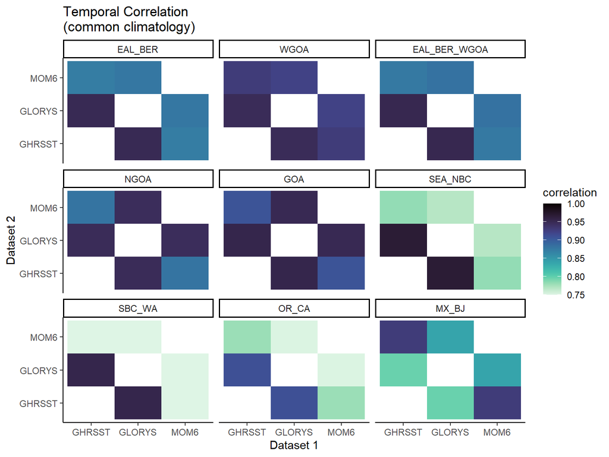

```r
cor_anom_df <- map(unique(mean_anom_df$zone_ord),\(z){
  mean_anom_df |> filter(zone_ord==z) |>
    dplyr::select(GLORYS,GHRSST,MOM6) |>
    cor(method='pearson') |>
    as_tibble(rownames = "data1") |>
    # make into longform
    pivot_longer(GLORYS:MOM6,names_to = "data2",values_to="correlation") |>
    mutate(zone_ord=z)
}) |> list_rbind()

cor_anom2_df <- map(unique(mean_anom2_df$zone_ord),\(z){
  mean_anom2_df |> filter(zone_ord==z) |>
    dplyr::select(GLORYS,GHRSST,MOM6) |>
    cor(method='pearson') |>
    as_tibble(rownames = "data1") |>
    # make into longform
    pivot_longer(GLORYS:MOM6,names_to = "data2",values_to="correlation") |>
    mutate(zone_ord=z)
}) |> list_rbind()

cor_anom_df |>
  filter(correlation<1) |>
  ggplot(aes(data1,data2,fill=correlation))+
  geom_tile()+
  labs(x="Dataset 1",y="Dataset 2",title="Temporal Correlation\n(common climatology)")+
  scale_fill_viridis(option = "G",direction=-1,limits=c(0.75,1),oob=scales::squish)+
  facet_wrap(~zone_ord)
```

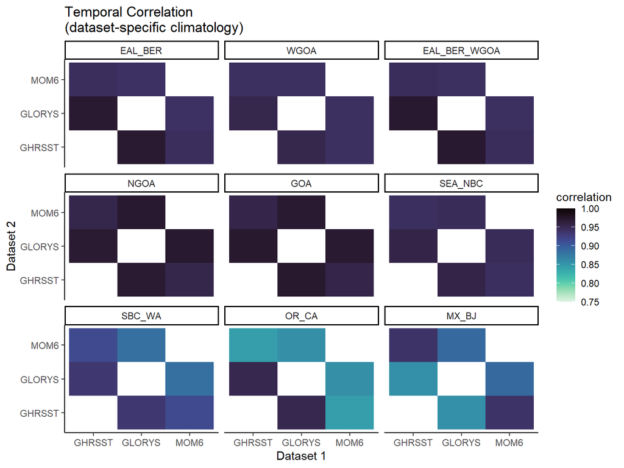

```r
cor_anom2_df |>
  filter(correlation<1) |>
  ggplot(aes(data1,data2,fill=correlation))+
  geom_tile()+
  labs(x="Dataset 1",y="Dataset 2",title="Temporal Correlation\n(dataset-specific climatology)")+
  scale_fill_viridis(option = "G",direction=-1,limits=c(0.75,1),oob=scales::squish)+
  facet_wrap(~zone_ord)
```

Anomaly correlation is high, especially using the dataset-specific climatology.